# Degrees of GPT Detector Bias

Statistically Delving into the Distinct Differences in Bias Discovered in GPT Detector Predictions

Author

Affiliation

[Jared Parker](https://arizona.digication.com/eportfolio-for-j-parker)

[University of Arizona](https://azcast.arizona.edu)

Published

October 11, 2023

Abstract

This study examines the impact of AI programs, such as GPT models, on education, with a focus on GPT detectors’ use to distinguish AI-generated content. Building on Liang et al.’s work, we explore biases against non-native English speakers in GPT detectors. Our analysis of 179 essays, including TOEFL and ASAP essays, reveals inherent bias. GPT detectors often misclassify non-native English work, leading to consequences in educational settings.

GPT detectors are commonly used programs in schools and universities to detect whether a writing sample has any content that was generated from an artificial intelligence. After reviewing information regarding bias inherent in GPT detectors, a question surrounding the degree of that bias was drawn forth. The study, detailed in **Review of the literature**, by Liang et al. (2023) found the presence of the aforementioned bias, but not the strength of each GPT detector’s bias. Their research catalyzed the experiment performed in my own study detailed later in this document.

## 1 Review of the literature

A common outcry against artificial intelligence revolves around the ramifications that AI-based programs like ChatGPT, a generative language model, will have on the educational system. These programs are often used in the pursuit of completing writing-based assignments and, in an effort to combat this, educators are employing the use of GPT detectors. These detectors purport to accurately predict whether a writing sample is AI or human authored. At surface level this appears commendable, but the use of these detectors brings with it unforeseen ramifications, just as artificial intelligence has.

The study performed by Liang et al. (2023) delves into the inherent bias inadvertently programmed within GPT detectors that produces discriminatory results against non-native English speakers. The authors accomplish this by amalgamating writing samples that consisted of 91 Test of English Language (TOEFL) essays from a Chinese forum and 88 Automated Student Assessment Prize (ASAP) essays written by U.S.A. eighth grade students from the Hewlett Foundation. Essays written or modified by GPT models are also purposefully included to strengthen their argument. These are then evaluated by a GPT detector (seven widely-used GPT detectors were utilized) which determines whether the essay is written by a human or by an Artificial Intelligence (AI). The detectors probability that the essay was written by an AI was such that a value greater than $0.5$ represented an AI written essay. This is the GPT detectors alpha value, where the null hypothesis that the essay is written by an AI is accepted or rejected. That null hypothesis is in regards to the GPT detector and should not be confused with the null hypothesis for the experiment which will be discussed below. The alpha value of $0.5$ however is relevant as it is the threshold for which the experiment also evaluates the AI or human written nature of the essays. These results act as a baseline or control for the experiment where the researchers modify the original essays with GPT models, prompting the AI to either elevate the language of essays classified as AI written (reducing detection rate) or simplify the language of essays classified as human written (increasing detection rate) and re-evaluate them using those same GPT detectors. Their research determined an average false-positive rate of $61.3%$ within the seven GPT detectors tested. This process exhibits a fundamental knowledge of the necessity of control groups, clearly defined evaluation parameters, and application of variable manipulation that solidifies their argument that GPT detectors are biased against non-native English speakers.

A hypothesis of observed bias within GPT detectors being connected to both diction typical of non-native English authors and reduced linguistic capabilities demonstrated within the written work was the focus of the experiment. The null hypothesis can be considered as there being no significant difference in the accuracy of GPT detectors on essays from native and non-native English authors, or on those with reduced linguistic capabilities. This was tested by obtaining a base P-value (AI authored at $P> 0.5$) for an essay. That essay would then be modified by a GPT program with a prompt based upon the detectors evaluation. If the essay was evaluated to be AI written, the GPT model was utilized to increase the use of literary language and mimic a native English writer in the pursuit of a human written classification. However, if it was evaluated to be human written, the essay was modified to have lower complexity and resemble that of a non-native English author with an expected result of being AI written. The modified essays were then processed through the GPT detectors for a new P-value with the same threshold as the control. The researchers compared these values and found the GPT detector’s classification is easily manipulated through engineering the GPT models prompt. A text sample of high enough literary complexity that emulates a native English speaker, whether human written, AI modified, or AI created, will show as human written when processed via GPT detection programs regardless of the voracity. The opposite is true as well, where written works from non-native English speakers or those with low linguistic variability will be falsely evaluated to be an AI written work. This stark illustration of the failings inherent in GPT detectors is beautifully painted with the comparison between the original classification (and P-value) and the manipulated classification (and associated P-value). Lacking from this study however is the detailed exploration of the relationship of each GPT detector and the essays.

## 2 Research problem

While the findings of the above study are commendable, the depths of each GPT detector’s bias is generalized through the focus of Liang et al. on the source of the essays. As Liang et al. (2023) say “All detectors unanimously identified 19.8% of the human-written TOEFL essays as AI authored, and at least one detector flagged 97.8% of TOEFL essays as AI generated”, which captures the heart of their research, but questions regarding the nature of each GPT detector’s bias are left unexplored. In this pursuit, statistical testing will be performed on the original data to determine correlation values, strength of correlation, and confidence level for each GPT detector’s relationship with the essay source. The results will then be compared to determine the difference between each GPT detector’s bias.

## 3 Design

The data used in this project is part of the `tidytuesday` project (Mock, 2021).

**Data Sorted by Detector Type:**

Detector: *Crossplag*

| prediction | pvalue | name | binaryname |
| --- | --- | --- | --- |
| AI | 8.281448e-01 | Real TOEFL | 1 |
| Human | 6.526799e-03 | US 8th grade essay | 0 |
| Human | 1.697856e-01 | Real TOEFL | 1 |
| Human | 1.679050e-04 | US 8th grade essay | 0 |
| Human | 1.956279e-02 | Real TOEFL | 1 |
| Human | 2.090879e-02 | Real TOEFL | 1 |
| Human | 1.744070e-04 | US 8th grade essay | 0 |
| AI | 9.754654e-01 | Real TOEFL | 1 |
| Human | 2.343310e-04 | US 8th grade essay | 0 |
| AI | 9.973204e-01 | US 8th grade essay | 0 |
| Human | 1.711520e-04 | US 8th grade essay | 0 |
| Human | 1.195259e-01 | Real TOEFL | 1 |
| Human | 1.158842e-01 | US 8th grade essay | 0 |
| Human | 1.695950e-04 | US 8th grade essay | 0 |
| AI | 6.925868e-01 | US 8th grade essay | 0 |
| AI | 7.607120e-01 | US 8th grade essay | 0 |
| Human | 5.395040e-04 | US 8th grade essay | 0 |
| Human | 2.766677e-01 | Real TOEFL | 1 |
| Human | 1.698400e-04 | US 8th grade essay | 0 |
| AI | 6.914328e-01 | US 8th grade essay | 0 |
| Human | 1.838330e-04 | US 8th grade essay | 0 |
| AI | 9.917828e-01 | Real TOEFL | 1 |
| AI | 9.390169e-01 | Real TOEFL | 1 |
| Human | 1.064476e-01 | Real TOEFL | 1 |
| Human | 6.139386e-02 | US 8th grade essay | 0 |
| AI | 9.101863e-01 | Real TOEFL | 1 |
| Human | 2.495530e-04 | US 8th grade essay | 0 |
| Human | 2.109930e-04 | US 8th grade essay | 0 |
| Human | 3.501326e-01 | Real TOEFL | 1 |
| Human | 3.249480e-04 | US 8th grade essay | 0 |

[output cut: 149 more lines]

*GPTZero*

| prediction | pvalue | name | binaryname |
| --- | --- | --- | --- |
| Human | 4.087193e-03 | Real TOEFL | 1 |
| Human | 6.670000e-24 | US 8th grade essay | 0 |
| AI | 6.535214e-01 | Real TOEFL | 1 |
| Human | 1.450000e-11 | US 8th grade essay | 0 |
| Human | 6.040000e-16 | US 8th grade essay | 0 |
| Human | 2.810000e-31 | US 8th grade essay | 0 |
| Human | 3.436239e-01 | Real TOEFL | 1 |
| Human | 3.436239e-01 | Real TOEFL | 1 |
| Human | 1.710000e-08 | US 8th grade essay | 0 |
| AI | 6.535214e-01 | Real TOEFL | 1 |
| AI | 7.145452e-01 | Real TOEFL | 1 |
| Human | 1.120000e-25 | US 8th grade essay | 0 |
| Human | 6.780000e-21 | US 8th grade essay | 0 |
| Human | 2.590000e-13 | US 8th grade essay | 0 |
| Human | 1.940000e-12 | US 8th grade essay | 0 |
| Human | 2.279298e-03 | Real TOEFL | 1 |
| Human | 2.950000e-11 | US 8th grade essay | 0 |
| Human | 1.762885e-01 | Real TOEFL | 1 |
| Human | 1.681530e-04 | US 8th grade essay | 0 |
| Human | 1.070000e-10 | US 8th grade essay | 0 |
| AI | 9.103422e-01 | Real TOEFL | 1 |
| Human | 3.450000e-14 | US 8th grade essay | 0 |
| Human | 4.355389e-01 | Real TOEFL | 1 |
| AI | 8.254777e-01 | Real TOEFL | 1 |
| Human | 8.100000e-07 | US 8th grade essay | 0 |
| Human | 4.640000e-33 | US 8th grade essay | 0 |
| Human | 8.460000e-33 | US 8th grade essay | 0 |
| Human | 3.020000e-33 | US 8th grade essay | 0 |
| Human | 1.470000e-05 | US 8th grade essay | 0 |
| Human | 3.000000e-07 | Real TOEFL | 1 |

[output cut: 149 more lines]

*HFOpenAI*

| prediction | pvalue | name | binaryname |
| --- | --- | --- | --- |
| AI | 7.118352e-01 | Real TOEFL | 1 |
| Human | 4.829610e-04 | US 8th grade essay | 0 |
| Human | 3.985048e-02 | US 8th grade essay | 0 |
| AI | 9.985637e-01 | Real TOEFL | 1 |
| AI | 9.997743e-01 | Real TOEFL | 1 |
| Human | 2.178330e-04 | US 8th grade essay | 0 |
| Human | 1.144070e-01 | Real TOEFL | 1 |
| AI | 7.840129e-01 | Real TOEFL | 1 |
| AI | 9.969873e-01 | Real TOEFL | 1 |
| Human | 1.956370e-04 | US 8th grade essay | 0 |
| AI | 9.973300e-01 | US 8th grade essay | 0 |
| Human | 1.391255e-01 | Real TOEFL | 1 |
| AI | 6.938172e-01 | Real TOEFL | 1 |
| Human | 1.893270e-04 | US 8th grade essay | 0 |
| AI | 9.164817e-01 | Real TOEFL | 1 |
| Human | 2.545480e-04 | US 8th grade essay | 0 |
| AI | 6.377771e-01 | Real TOEFL | 1 |
| AI | 9.411811e-01 | Real TOEFL | 1 |
| AI | 8.682210e-01 | Real TOEFL | 1 |
| Human | 5.167957e-02 | US 8th grade essay | 0 |
| Human | 1.876470e-04 | US 8th grade essay | 0 |
| Human | 4.768420e-04 | US 8th grade essay | 0 |
| Human | 1.584011e-01 | Real TOEFL | 1 |
| Human | 5.423200e-03 | Real TOEFL | 1 |
| Human | 1.247251e-01 | Real TOEFL | 1 |
| Human | 1.702143e-02 | Real TOEFL | 1 |
| Human | 2.278620e-04 | US 8th grade essay | 0 |
| Human | 3.513630e-04 | US 8th grade essay | 0 |
| AI | 7.765508e-01 | Real TOEFL | 1 |
| Human | 2.465980e-04 | US 8th grade essay | 0 |

[output cut: 149 more lines]

*OriginalityAI*

| prediction | pvalue | name | binaryname |
| --- | --- | --- | --- |
| Human | 4.000000e-04 | US 8th grade essay | 0 |
| AI | 9.922405e-01 | Real TOEFL | 1 |
| Human | 4.500000e-03 | US 8th grade essay | 0 |
| Human | 1.341500e-01 | US 8th grade essay | 0 |
| AI | 8.633461e-01 | Real TOEFL | 1 |
| Human | 6.200000e-03 | US 8th grade essay | 0 |
| Human | 4.000000e-04 | US 8th grade essay | 0 |
| AI | 9.182856e-01 | Real TOEFL | 1 |
| Human | 2.000000e-04 | US 8th grade essay | 0 |
| Human | 5.000000e-04 | US 8th grade essay | 0 |
| AI | 9.993650e-01 | Real TOEFL | 1 |
| AI | 9.757437e-01 | Real TOEFL | 1 |
| Human | 3.510000e-02 | US 8th grade essay | 0 |
| AI | 9.738470e-01 | Real TOEFL | 1 |
| Human | 3.000000e-04 | US 8th grade essay | 0 |
| Human | 6.200000e-03 | US 8th grade essay | 0 |
| AI | 9.707763e-01 | Real TOEFL | 1 |
| Human | 1.000000e-04 | US 8th grade essay | 0 |
| AI | 9.816912e-01 | Real TOEFL | 1 |
| Human | 3.000000e-04 | US 8th grade essay | 0 |
| AI | 9.862822e-01 | Real TOEFL | 1 |
| Human | 5.500000e-04 | US 8th grade essay | 0 |
| Human | 1.200000e-03 | US 8th grade essay | 0 |
| Human | 2.000000e-04 | US 8th grade essay | 0 |
| Human | 9.000000e-04 | US 8th grade essay | 0 |
| AI | 9.768531e-01 | Real TOEFL | 1 |
| Human | 9.000000e-04 | US 8th grade essay | 0 |
| AI | 9.899726e-01 | Real TOEFL | 1 |
| Human | 3.000000e-04 | US 8th grade essay | 0 |
| Human | 5.000000e-04 | US 8th grade essay | 0 |

[output cut: 149 more lines]

*Quil*

| prediction | pvalue | name | binaryname |
| --- | --- | --- | --- |
| AI | 9.964566e-01 | Real TOEFL | 1 |
| Human | 6.100315e-02 | Real TOEFL | 1 |
| Human | 2.024277e-01 | Real TOEFL | 1 |
| Human | 1.704690e-04 | US 8th grade essay | 0 |
| Human | 1.955630e-04 | US 8th grade essay | 0 |
| AI | 9.998246e-01 | Real TOEFL | 1 |
| Human | 1.660109e-03 | US 8th grade essay | 0 |
| Human | 2.842637e-01 | US 8th grade essay | 0 |
| Human | 2.807747e-01 | US 8th grade essay | 0 |
| AI | 9.949195e-01 | US 8th grade essay | 0 |
| AI | 6.220326e-01 | US 8th grade essay | 0 |
| AI | 8.191974e-01 | US 8th grade essay | 0 |
| Human | 4.905320e-01 | Real TOEFL | 1 |
| Human | 2.297396e-02 | Real TOEFL | 1 |
| Human | 2.169010e-04 | US 8th grade essay | 0 |
| AI | 8.635845e-01 | Real TOEFL | 1 |
| AI | 9.991016e-01 | Real TOEFL | 1 |
| Human | 3.981934e-01 | Real TOEFL | 1 |
| AI | 9.998215e-01 | Real TOEFL | 1 |
| AI | 9.998195e-01 | Real TOEFL | 1 |
| AI | 9.998223e-01 | Real TOEFL | 1 |
| AI | 7.107153e-01 | Real TOEFL | 1 |
| Human | 9.194970e-03 | US 8th grade essay | 0 |
| AI | 9.993048e-01 | Real TOEFL | 1 |
| AI | 9.998192e-01 | Real TOEFL | 1 |
| Human | 2.157090e-04 | US 8th grade essay | 0 |
| AI | 7.451370e-01 | Real TOEFL | 1 |
| Human | 6.378290e-04 | US 8th grade essay | 0 |
| Human | 1.958010e-04 | US 8th grade essay | 0 |
| AI | 9.662563e-01 | US 8th grade essay | 0 |

[output cut: 149 more lines]

*Sapling*

| prediction | pvalue | name | binaryname |
| --- | --- | --- | --- |
| AI | 9.999942e-01 | Real TOEFL | 1 |
| AI | 9.999993e-01 | Real TOEFL | 1 |
| Human | 1.970000e-05 | US 8th grade essay | 0 |
| Human | 1.040000e-06 | US 8th grade essay | 0 |
| AI | 9.999996e-01 | Real TOEFL | 1 |
| Human | 3.894316e-03 | Real TOEFL | 1 |
| AI | 9.701206e-01 | US 8th grade essay | 0 |
| Human | 1.125797e-01 | US 8th grade essay | 0 |
| Human | 5.310000e-06 | Real TOEFL | 1 |
| AI | 9.999990e-01 | Real TOEFL | 1 |
| Human | 7.120000e-06 | US 8th grade essay | 0 |
| Human | 7.200000e-07 | Real TOEFL | 1 |
| Human | 2.471960e-04 | US 8th grade essay | 0 |
| Human | 9.920000e-07 | US 8th grade essay | 0 |
| AI | 9.999681e-01 | Real TOEFL | 1 |
| Human | 9.650000e-05 | Real TOEFL | 1 |
| Human | 5.370000e-07 | US 8th grade essay | 0 |
| Human | 8.519030e-04 | Real TOEFL | 1 |
| Human | 9.055453e-02 | US 8th grade essay | 0 |
| Human | 2.655205e-01 | US 8th grade essay | 0 |
| Human | 5.080000e-07 | US 8th grade essay | 0 |
| Human | 1.584277e-02 | US 8th grade essay | 0 |
| Human | 4.010000e-06 | US 8th grade essay | 0 |
| Human | 5.850000e-07 | US 8th grade essay | 0 |
| Human | 2.460000e-06 | Real TOEFL | 1 |
| AI | 9.999834e-01 | Real TOEFL | 1 |
| Human | 6.930000e-07 | US 8th grade essay | 0 |
| AI | 9.999877e-01 | Real TOEFL | 1 |
| AI | 9.972968e-01 | Real TOEFL | 1 |
| AI | 9.999807e-01 | Real TOEFL | 1 |

[output cut: 149 more lines]

*ZeroGPT*

| prediction | pvalue | name | binaryname |
| --- | --- | --- | --- |
| AI | 8.75e-01 | Real TOEFL | 1 |
| Human | 0.00e+00 | Real TOEFL | 1 |
| Human | 0.00e+00 | US 8th grade essay | 0 |
| Human | 0.00e+00 | US 8th grade essay | 0 |
| Human | 0.00e+00 | US 8th grade essay | 0 |
| Human | 2.50e-01 | US 8th grade essay | 0 |
| Human | 1.25e-01 | Real TOEFL | 1 |
| AI | 7.50e-01 | Real TOEFL | 1 |
| Human | 2.50e-01 | Real TOEFL | 1 |
| Human | 2.50e-01 | Real TOEFL | 1 |
| Human | 5.00e-01 | US 8th grade essay | 0 |
| Human | 0.00e+00 | US 8th grade essay | 0 |
| Human | 0.00e+00 | US 8th grade essay | 0 |
| Human | 0.00e+00 | Real TOEFL | 1 |
| Human | 0.00e+00 | Real TOEFL | 1 |
| Human | 0.00e+00 | US 8th grade essay | 0 |
| Human | 0.00e+00 | US 8th grade essay | 0 |
| AI | 8.75e-01 | Real TOEFL | 1 |
| Human | 2.50e-01 | Real TOEFL | 1 |
| Human | 0.00e+00 | US 8th grade essay | 0 |
| AI | 6.25e-01 | Real TOEFL | 1 |
| Human | 0.00e+00 | US 8th grade essay | 0 |
| Human | 2.50e-01 | Real TOEFL | 1 |
| AI | 6.25e-01 | Real TOEFL | 1 |
| Human | 2.50e-01 | Real TOEFL | 1 |
| Human | 0.00e+00 | US 8th grade essay | 0 |
| Human | 0.00e+00 | US 8th grade essay | 0 |
| Human | 0.00e+00 | US 8th grade essay | 0 |
| Human | 0.00e+00 | US 8th grade essay | 0 |
| Human | 5.00e-01 | Real TOEFL | 1 |

[output cut: 149 more lines]

If the average Pvalue assigned to TOEFl sourced essays is equal to the average Pvalue assigned to U.S.A. 8th grader sourced essays, then the detector has no bias. However, if bias is detected, then the strength of that bias can be measured by the relative strength of the correlation with which the detector falsely assigns an AI prediction. The raw data comes from the tidytuesday dataset, GPT detectors, and is derived from the study performed by Liang et al. (2023). The Pvalues and predictions associated with the TOEFL and U.S.A eighth grader essays are selected from the raw data and further categorized into tables by GPT detector type (Crossplag, GPTZero, HFOpenAI, OriginalityAI, Quil, Sapling, and ZeroGPT). This data coercion also removes any values associated with AI generated or modified documents, leaving only human-associated datapoints, where the GPT detector predictions of “AI” are false and the predictions of “Human” are true. Strength of bias is then represented by the extremity of Pvalue with which a detector assigns the AI predictions to a certain source. The source of the essays are evaluated and assigned a value of either $0$ or $1$, where $0$ represents a U.S.A. 8th grader essay and $1$ represents a TOEFL essay which is then stored in the $binaryname$ column. This consistent assignment of value to source-type is performed to alias the source-type into a numerical value for later analysis.

The Pvalues for each detector are quantitative representations of the level of bias within that detector, where a tendency towards producing Pvalues greater than $0.5$ denotes a bias towards AI predictions and a tendency towards producing Pvalues less than $0.5$ denotes a bias towards Human predictions. These trends can then be further explored by determining if the average Pvalue assigned is dependent on the essay source through Pearson Correlation Coefficient Analysis tests via the source-type aliasing explained in the above paragraph. The correlation between the average Pvalue assigned to an essay and the essay source can be described as the average Pvalue assigned being dependent on the essay’s binaryname value. This results in negative correlations being associated with USA 8th grader essays having higher average Pvalues and positive correlations with TOEFL essays having higher average Pvalues. Identifying which source is more likely to have higher average Pvalues also identifies which source has a higher chance of being classified as being AI written. According to the findings from Liang et al. (2023), the correlations for each detector should be positive as that demonstrates the detector’s bias of classifying TOEFL essays as being AI written. The strength of that bias however can be measured by comparing the correlation coefficient to a value of $0$ as $0$ represents no correlation or connection between the Pvalue (and associated prediction) assigned to an essay and that essay’s source. A coefficient value between $0 - 0.4$ will show weak bias, $0.4 - 0.8$ shows moderate bias, and $0.8 - 1.0$ shows strong bias.

## 4 Results

| detector | mean_pvalue | sd_pvalue | var_pvalue |
| --- | --- | --- | --- |
| Crossplag | 0.3202953 | 0.3851382 | 0.1483314 |
| GPTZero | 0.2265246 | 0.3531621 | 0.1247235 |
| HFOpenAI | 0.3317059 | 0.4018404 | 0.1614757 |
| OriginalityAI | 0.3962079 | 0.4526358 | 0.2048792 |
| Quil | 0.4108007 | 0.4399289 | 0.1935374 |
| Sapling | 0.3826393 | 0.4711906 | 0.2220206 |
| ZeroGPT | 0.2632682 | 0.3400088 | 0.1156060 |

Common descriptive statistic measurements for the Pvalue of each detector.

The GPT detector Quil has the highest mean Pvalue (0.4108007) of the seven detectors, which denotes the detector that returns higher pvalues on average. Quil’s standard deviation of 0.4399289, represents the spread or dispersion of the data points around the mean and is computed from the variance (contained in the var_pvalue column). A higher standard deviation suggests that the data points are more spread out from the mean, while a lower standard deviation indicates that the data points are closer to the mean. This demonstrates how much variety exists within the Pvalues.

The detector with the lowest mean Pvalue is GPTZero, with a value of 0.2265246. This detector also has the second lowest standard deviation (0.3531621).

Comparing the above values for Quil and GPTZero, a prediction of Quil containing the strongest bias, and GPTZero containing the weakest can be made and will be tested by the Pearson Correlation Coefficient Analysis tests.

The histograms below illustrate how often each detector predicts an essay is Human or AI authored.

**Frequency Histograms of AI and Human Predictions per GPT Detector**

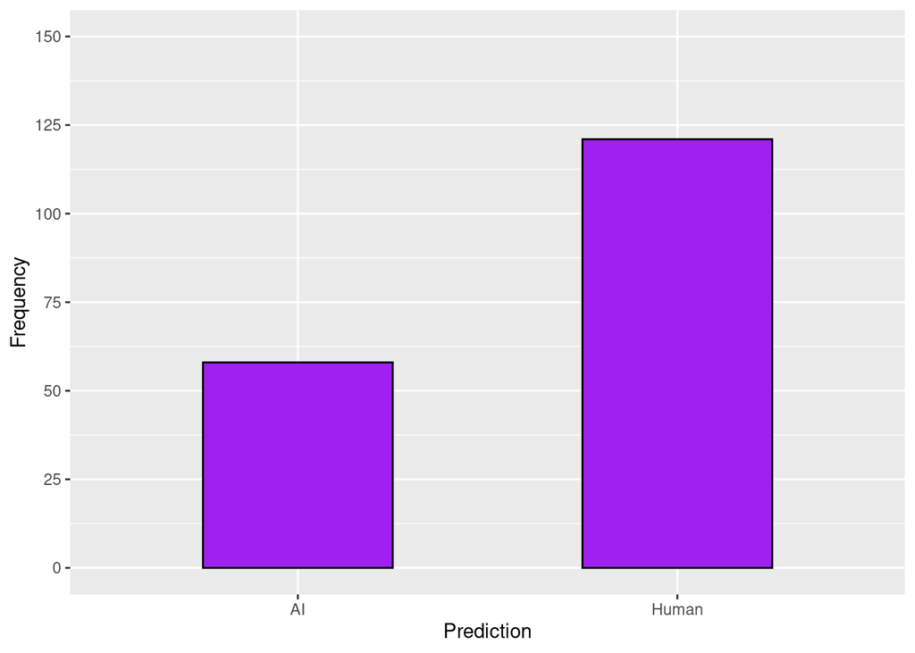

Frequency of AI and Human predictions for Crossplag GPT Detector

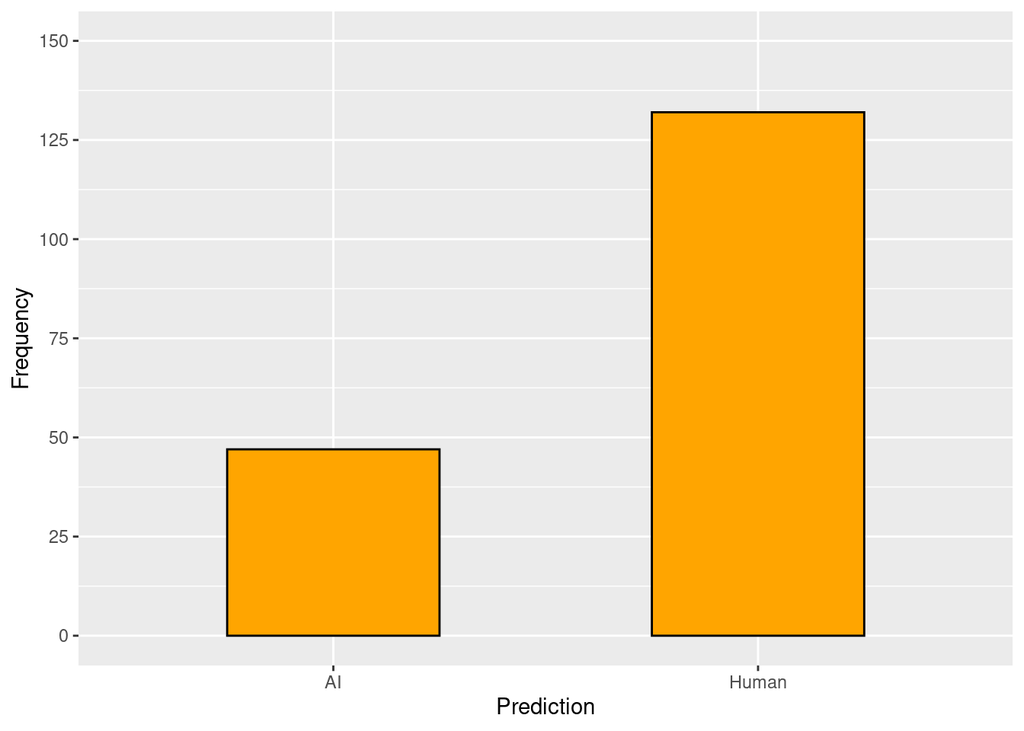

Frequency of AI and Human predictions for GPTZero GPT Detector

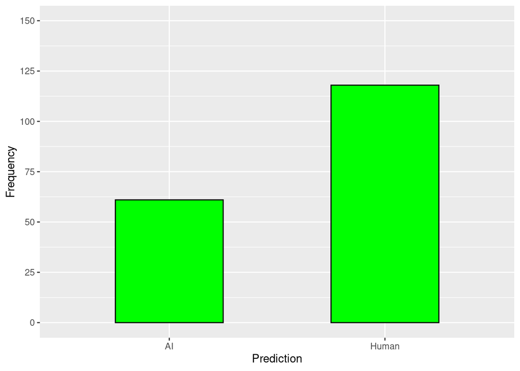

Frequency of AI and Human predictions for HFOpenAI GPT Detector

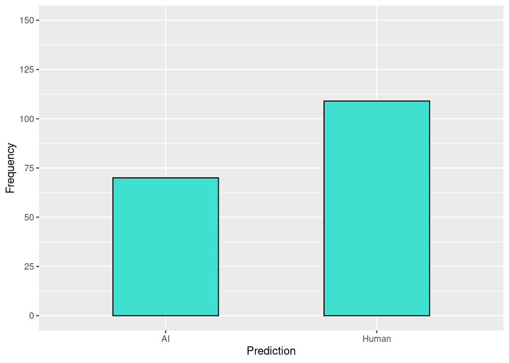

Frequency of AI and Human predictions for OriginalityAI GPT Detector

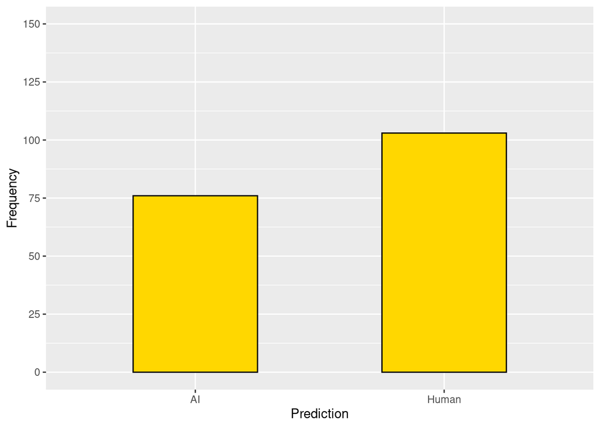

Frequency of AI and Human predictions for Quil GPT Detector

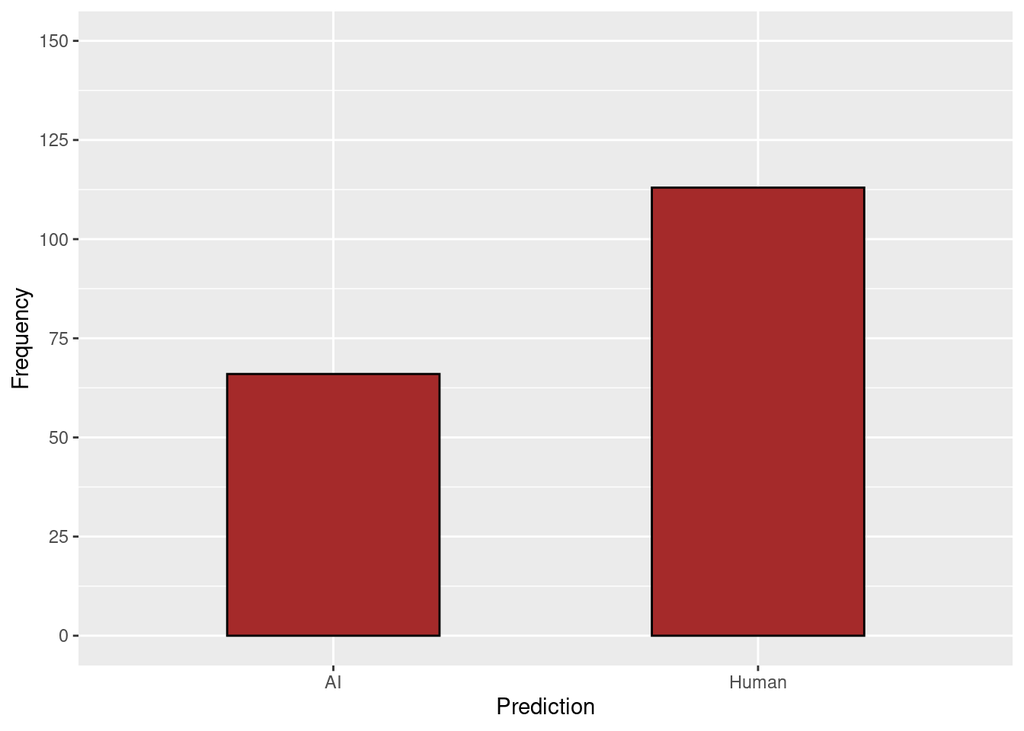

Frequency of AI and Human predictions for Sapling GPT Detector

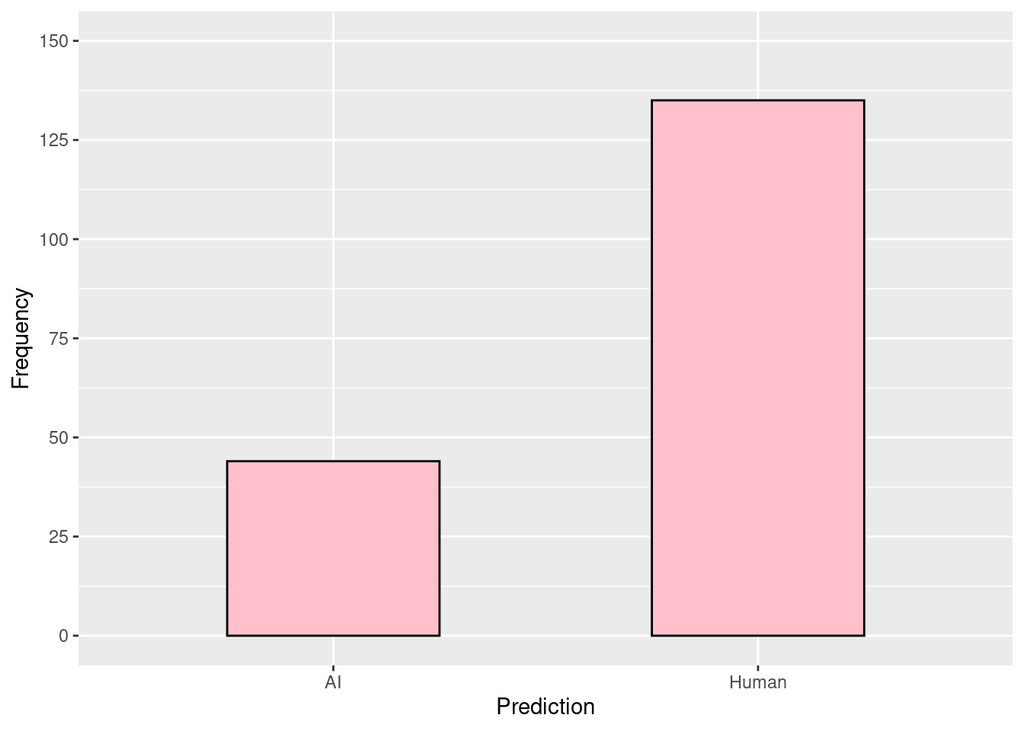

Frequency of AI and Human predictions for ZeroGPT GPT Detector

The below tables contain the correlation coefficient and p-values for each detector’s Pearson Correlation Coefficient Analysis test.

**Tables Containing Correlation values and P-values for Each Detector**

|  | Correlation_Value | PValue | Method |
| --- | --- | --- | --- |
| cor | 0.5195333 | 9.203449e-14 | Pearson’s product-moment correlation |

Correlation values for Crossplag

|  | Correlation_Value | PValue | Method |
| --- | --- | --- | --- |
| cor | 0.6246781 | 9.239029e-21 | Pearson’s product-moment correlation |

Correlation values for GPTZero

|  | Correlation_Value | PValue | Method |
| --- | --- | --- | --- |
| cor | 0.5718277 | 6.241605e-17 | Pearson’s product-moment correlation |

Correlation values for HFOpenAI

|  | Correlation_Value | PValue | Method |
| --- | --- | --- | --- |
| cor | 0.789408 | 2.333319e-39 | Pearson’s product-moment correlation |

Correlation values for OriginalityAI

|  | Correlation_Value | PValue | Method |
| --- | --- | --- | --- |
| cor | 0.7017231 | 7.348793e-28 | Pearson’s product-moment correlation |

Correlation values for Quil

|  | Correlation_Value | PValue | Method |
| --- | --- | --- | --- |
| cor | 0.6495973 | 7.827025e-23 | Pearson’s product-moment correlation |

Correlation values for Sapling

|  | Correlation_Value | PValue | Method |
| --- | --- | --- | --- |
| cor | 0.6770484 | 2.370548e-25 | Pearson’s product-moment correlation |

Correlation values for ZeroGPT

The correlation values in the table denote the strength and direction of the bias within each detector and the Pvalues (which are **not** the mean Pvalues) show how likely the correlation values are to happen by chance. Statistical significance can be determined by comparing these correlation Pvalues to an alpha value of $0.001$. Each detector’s correlation Pvalue (9.203449e-14, 9.239029e-21, 6.241605e-17, 2.333319e-39, 7.348793e-28, 7.827025e-23, 2.370548e-25) is much lower than the $0.001$ alpha value, demonstrating the accuracy and significance of the results.

The detectors all show a positive correlation, once again demonstrating the bias in all seven GPT detectors. In contrast with the earlier prediction, the strongest bias (one of moderate strength) is illustrated by the highest correlation value of 0.789408, associated with the OriginalityAI detector. Quil was expected to have the strongest, but only has a correlation value of 0.7017231. The detector Crossplag has the weakest bias (one of moderate strength) with a correlation value of 0.5195333 while the expected weakest, GPTZero, has a correlation value of 0.6246781.

The degree of OriginalityAI and Crossplag’s bias can be further confirmed via comparing the two essay sources, TOEFL and U.S.A. 8th grader, and their associated Pvalues through a t test. The The results are shown below.

|  | originalityai_ttest.statistic | crossplag_ttest.statistic |
| --- | --- | --- |
| t | 17.33777 | 8.125498 |

T Test for Crossplag and OriginalityAI detector

The statistic values represent the level of extremity and variability between the detector assigned Pvalues to TOEFL essays and those assigned to U.S.A. 8th graders. The higher value of 17.3377656 represents the level of difference between the two sources when processed by the OriginalityAI GPT detector.

## 5 Discussion

While the above findings corroborate the results from Liang et al. (2023), they are surprising due to the contrast between the initial predictions based on mean Pvalues and the statistically significant predictions calculated from the correlation values and strengths. The degree of bias should be taken into consideration when discussing the individual detectors, but due to the strength of all detectors falling within the moderate category ($0.4 < CorrelationValue <0.8$), all seven detectors should be used with caution. The results of this study should demonstrate the need to use GPT detectors with a full understanding of their limitations, and any detector generated predictions should be taken with a grain of salt.

## 6 References

Liang, W., Yuksekgonul, M., Mao, Y., Wu, E., & Zou, J. (2023). GPT detectors are biased against non-native english writers. *Patterns*, *4*(7), 100779. https://doi.org/10.1016/j.patter.2023.100779

Mock, T. (2021). *Tidy tuesday: A weekly data project aimed at the r ecosystem*. https://github.com/rfordatascience/tidytuesday

## Citation

BibTeX citation:

```
@online{parker2023,
  author = {Parker, Jared},
  title = {Degrees of {GPT} {Detector} {Bias}},
  date = {2023-10-11},
  langid = {en},
  abstract = {This study examines the impact of AI programs, such as GPT
    models, on education, with a focus on GPT detectors’ use to
    distinguish AI-generated content. Building on Liang et al.’s work,
    we explore biases against non-native English speakers in GPT
    detectors. Our analysis of 179 essays, including TOEFL and ASAP
    essays, reveals inherent bias. GPT detectors often misclassify
    non-native English work, leading to consequences in educational
    settings.}
}
```

For attribution, please cite this work as:

Parker, J. (2023, October 11). *Degrees of GPT Detector Bias*.